# 08：跨基因区间构造与 GFF 基因扫描总览

这个笔记本的前半部分主要完成两件事：

1. 从 `pairs_deduplicated.csv` 中筛出 `block_orientation == "r"` 的共线性区块，并在 A 染色体上构造跨基因区间。
2. 从 GFF 文件中提取 `gene` 记录，把每个基因看成染色体上的一个区间，再判断它与这些跨基因区间的相对位置。

## 一、跨基因区间如何构造

这里的区间不是直接读取出来的固定注释区间，而是根据共线性基因对的相邻关系构造的：

- 先按 `block_uid` 对反向区块分组。
- 在每个区块内，按 `genome_order1` 对 A 染色体上的锚定基因排序。
- 对相邻两条记录 `i` 和 `i+1`，取前一条的 `stop1[i]` 和后一条的 `start1[i+1]`。
- 用这两个位置定义一个跨基因区间；如果两端顺序相反，就交换两端，保证 `interval_start <= interval_end`。

因此，每个区间表示的是：**同一个反向共线性区块内，相邻两个锚定基因之间跨过去的 A 染色体片段**。

## 二、GFF 基因和区间的位置如何定义

在 GFF 扫描部分：

- 只保留特征类型等于 `gene` 的记录。
- 每个基因都被看作同一条染色体上的闭区间 `[gene_start, gene_end]`。
- 每个跨基因区间也被看作闭区间 `[interval_start, interval_end]`。
- 只在同一条染色体上比较基因和区间的位置关系。
- 有效重叠定义为：`overlap_bp = min(gene_end, interval_end) - max(gene_start, interval_start) + 1`。
- 只有当 `overlap_bp >= 3` 时，才算基因与区间真正重叠；端点接触或只有 1 到 2 bp 的微小接触都不计入。

在这个定义下，每个基因最终会被分到 `outside`、`inside`、`partial_overlap` 或 `spanning_multiple` 这几类位置关系中。

## 三、当前主要统计结果

- `block_orientation == "r"` 的原始 pair 记录数：11,307
- 反向共线性区块数量：591
- 最终构造出的跨基因区间数量：10,716
- 真正贡献出区间的反向共线性区块数量：548
- 完成位置分类的 GFF 基因总数：41,020
- `outside`：20,165
- `inside`：12,297
- `spanning_multiple`：8,557
- `partial_overlap`：1

这些结果说明：大量 GFF 基因完全落在这些跨基因区间之外，但也有相当一部分基因完整落入某一个区间；同时，`spanning_multiple` 的数量很高，说明这些构造出来的区间之间存在明显重叠，使得单个基因可能同时命中多个区间。后面的代码和说明会把这一部分的构造过程、分类规则和示例展开得更细。

```
Loaded pairs: (22229, 41)
Unique blocks (block_uid): 1246
```

|  | block_raw_id | block_score | a_label | b_label | block_orientation | n_pairs_reported | mean_ks_reported | mean_kn_reported | block_uid | Ks | ... | similarity | start1_raw | stop1_raw | start2_raw | stop2_raw | eval | row_block_score | pair_key | chrpair_key | block_signature_hash |
| --- | --- | --- | --- | --- | --- | --- | --- | --- | --- | --- | --- | --- | --- | --- | --- | --- | --- | --- | --- | --- | --- |
| 0 | 1 | 829.0 | a24668_A01 | b24668_A01 | r | 17 | 2.116 | 0.2686 | 1 | 8.8821 | ... | 70.7 | 11553894 | 11555345 | 19705913 | 19704077 | 1.000000e-250 | 50.0 | ('546250017', '546252953') | ('a24668_A01', 'b24668_A01') | 4795542eb433f64a7657cda6efa2e054 |
| 1 | 1 | 829.0 | a24668_A01 | b24668_A01 | r | 17 | 2.116 | 0.2686 | 1 | 1.6123 | ... | 72.2 | 11669461 | 11669168 | 19653246 | 19653617 | 1.900000e-64 | 97.0 | ('546250005', '546252979') | ('a24668_A01', 'b24668_A01') | 4795542eb433f64a7657cda6efa2e054 |
| 2 | 1 | 829.0 | a24668_A01 | b24668_A01 | r | 17 | 2.116 | 0.2686 | 1 | 2.7771 | ... | 73.3 | 11715305 | 11714430 | 19573067 | 19573759 | 9.300000e-134 | 147.0 | ('546249991', '546252989') | ('a24668_A01', 'b24668_A01') | 4795542eb433f64a7657cda6efa2e054 |

3 rows × 41 columns

```
Rows with block_orientation='r': 11307
Reverse-orientation blocks: 591
Constructed 10716 cross-gene intervals from 548 reverse-orientation blocks
Chromosomes covered: ['A01', 'A02', 'A03', 'A04', 'A05', 'A06', 'A07', 'A08', 'A09', 'A10']
```

|  | block_uid | chr1 | interval_start | interval_end | interval_length | left_gene_name | left_gene_stop1 | left_gene_start1 | left_similarity | right_gene_name | right_gene_start1 | right_gene_stop1 | right_similarity | block_orientation | chrpair_key |
| --- | --- | --- | --- | --- | --- | --- | --- | --- | --- | --- | --- | --- | --- | --- | --- |
| 0 | 1 | A01 | 11555345 | 11669168 | 113823 | Bra039545 | 11555345 | 11553894 | 70.7 | Bra039558 | 11669168 | 11669461 | 72.2 | r | ('a24668_A01', 'b24668_A01') |
| 1 | 1 | A01 | 11669461 | 11714430 | 44969 | Bra039558 | 11669461 | 11669168 | 72.2 | Bra039563 | 11714430 | 11715305 | 73.3 | r | ('a24668_A01', 'b24668_A01') |
| 2 | 1 | A01 | 11715305 | 11736978 | 21673 | Bra039563 | 11715305 | 11714430 | 73.3 | Bra039565 | 11736978 | 11737532 | 72.3 | r | ('a24668_A01', 'b24668_A01') |
| 3 | 1 | A01 | 11737532 | 11829391 | 91859 | Bra039565 | 11737532 | 11736978 | 72.3 | Bra040696 | 11829391 | 11832428 | 67.9 | r | ('a24668_A01', 'b24668_A01') |
| 4 | 1 | A01 | 11832428 | 11905279 | 72851 | Bra040696 | 11832428 | 11829391 | 67.9 | Bra036919 | 11905279 | 11905686 | 88.8 | r | ('a24668_A01', 'b24668_A01') |
| 5 | 1 | A01 | 11905686 | 11908930 | 3244 | Bra036919 | 11905686 | 11905279 | 88.8 | Bra036918 | 11908930 | 11912459 | 78.3 | r | ('a24668_A01', 'b24668_A01') |
| 6 | 1 | A01 | 11912459 | 11931476 | 19017 | Bra036918 | 11912459 | 11908930 | 78.3 | Bra036914 | 11931476 | 11933284 | 68.0 | r | ('a24668_A01', 'b24668_A01') |
| 7 | 1 | A01 | 11933284 | 11992538 | 59254 | Bra036914 | 11933284 | 11931476 | 68.0 | Bra036905 | 11992538 | 11993159 | 76.6 | r | ('a24668_A01', 'b24668_A01') |
| 8 | 1 | A01 | 11993159 | 11993551 | 392 | Bra036905 | 11993159 | 11992538 | 76.6 | Bra036904 | 11993551 | 11994979 | 87.4 | r | ('a24668_A01', 'b24668_A01') |
| 9 | 1 | A01 | 11994979 | 12049577 | 54598 | Bra036904 | 11994979 | 11993551 | 87.4 | Bra036900 | 12049577 | 12052924 | 75.3 | r | ('a24668_A01', 'b24668_A01') |

```
Overall overlap counts across all A chromosomes:
  chromosomes_counted: 10
  total_intervals: 10,716
  strict_overlap_pairs: 10,692
  unique_overlapping_intervals: 7,389
  endpoint_touching_pairs: 1

Per-chromosome overlap counts:
```

|  | chr1 | total_intervals | strict_overlap_pairs | unique_overlapping_intervals | endpoint_touching_pairs |
| --- | --- | --- | --- | --- | --- |
| 0 | A01 | 1818 | 2438 | 1521 | 0 |
| 1 | A02 | 2037 | 2196 | 1444 | 0 |
| 2 | A03 | 2502 | 1631 | 1434 | 0 |
| 3 | A04 | 1240 | 1545 | 901 | 0 |
| 4 | A05 | 589 | 583 | 436 | 0 |
| 5 | A06 | 1494 | 1695 | 1130 | 1 |
| 6 | A07 | 723 | 528 | 421 | 0 |
| 7 | A08 | 99 | 8 | 11 | 0 |
| 8 | A09 | 194 | 58 | 78 | 0 |
| 9 | A10 | 20 | 10 | 13 | 0 |

```
One example strict-overlap pair for each chromosome:
```

|  | chr1 | example_left_interval_id | example_right_interval_id | example_left_block_uid | example_right_block_uid | example_left_interval | example_right_interval | example_overlap_interval | example_overlap_span | example_left_genes | example_right_genes |
| --- | --- | --- | --- | --- | --- | --- | --- | --- | --- | --- | --- |
| 0 | A01 | 1463 | 1465 | 142 | 40 | [23145434, 23480616] | [23149732, 23480616] | [23149732, 23480616] | 330884 | Bra021099 -> Bra021594 | Bra021098 -> Bra021594 |
| 1 | A02 | 1621 | 1622 | 279 | 323 | [20997762, 21185632] | [20997762, 21229045] | [20997762, 21185632] | 187870 | Bra026509 -> Bra036363 | Bra026509 -> Bra036357 |
| 2 | A03 | 1933 | 1934 | 434 | 514 | [18956337, 19059401] | [18956337, 19105015] | [18956337, 19059401] | 103064 | Bra001857 -> Bra001862 | Bra001857 -> Bra001872 |
| 3 | A04 | 260 | 261 | 610 | 628 | [1579640, 1738823] | [1579640, 1738823] | [1579640, 1738823] | 159183 | Bra014581 -> Bra014608 | Bra014581 -> Bra014608 |
| 4 | A05 | 264 | 266 | 744 | 780 | [7024133, 7215196] | [7042866, 7218753] | [7042866, 7215196] | 172330 | Bra018267 -> Bra018286 | Bra018271 -> Bra018287 |
| 5 | A06 | 1292 | 1293 | 862 | 884 | [22541228, 22634742] | [22541228, 22634742] | [22541228, 22634742] | 93514 | Bra024817 -> Bra024834 | Bra024817 -> Bra024834 |
| 6 | A07 | 594 | 621 | 1548 | 949 | [22242419, 23665805] | [23202852, 23312422] | [23202852, 23312422] | 109570 | Bra016192 -> Bra015879 | Bra015992 -> Bra015964 |
| 7 | A08 | 32 | 33 | 1022 | 1037 | [10240850, 10368282] | [10327106, 10398203] | [10327106, 10368282] | 41176 | Bra020947 -> Bra020925 | Bra020932 -> Bra020921 |
| 8 | A09 | 165 | 171 | 1825 | 1070 | [29153967, 31483655] | [31424002, 31483655] | [31424002, 31483655] | 59653 | Bra007160 -> Bra007602 | Bra007586 -> Bra007602 |
| 9 | A10 | 1 | 2 | 2014 | 1990 | [4838045, 8117691] | [6713826, 7980225] | [6713826, 7980225] | 1266399 | Bra028306 -> Bra002712 | Bra002934 -> Bra002740 |

```
Saved cross-gene intervals → /Users/gufeng/2026_Winter/RA_Job/data/BrassicaRapa_id32114/results/cross_gene_intervals.csv
  Total intervals: 10716
  Mean interval length: 23588 bp
  Median interval length: 11055 bp
```

```
Parsed 41020 gene entries from GFF
Chromosomes: ['A01', 'A02', 'A03', 'A04', 'A05', 'A06', 'A07', 'A08', 'A09', 'A10', 'Scaffold000096', 'Scaffold000100', 'Scaffold000103', 'Scaffold000104', 'Scaffold000111'] ...
```

|  | chr | gene_start | gene_end | strand | gene_name | raw_attributes |
| --- | --- | --- | --- | --- | --- | --- |
| 0 | A01 | 8426 | 10051 | - | Bra011902 | ID=Bra011902;Name=Bra011902;Alias=Bra011902;ge... |
| 1 | A01 | 10565 | 11413 | + | Bra011901 | ID=Bra011901;Name=Bra011901;Alias=Bra011901;ge... |
| 2 | A01 | 14267 | 17822 | + | Bra011900 | ID=Bra011900;Name=Bra011900;Alias=Bra011900;ge... |
| 3 | A01 | 19283 | 20267 | - | Bra011899 | ID=Bra011899;Name=Bra011899;Alias=Bra011899;ge... |
| 4 | A01 | 21525 | 22611 | + | Bra011898 | ID=Bra011898;Name=Bra011898;Alias=Bra011898;ge... |

```
Minimum overlap counted: 3 bp
Classification summary:
classification
outside              20165
inside               12297
spanning_multiple     8557
partial_overlap          1
Name: count, dtype: int64

Total genes classified: 41020
```

|  | chr | gene_start | gene_end | gene_name | strand | classification | n_overlapping_intervals | interval_info | block_uids |
| --- | --- | --- | --- | --- | --- | --- | --- | --- | --- |
| 0 | A01 | 8426 | 10051 | Bra011902 | - | outside | 0 |  |  |
| 1 | A01 | 10565 | 11413 | Bra011901 | + | outside | 0 |  |  |
| 2 | A01 | 14267 | 17822 | Bra011900 | + | outside | 0 |  |  |
| 3 | A01 | 19283 | 20267 | Bra011899 | - | outside | 0 |  |  |
| 4 | A01 | 21525 | 22611 | Bra011898 | + | inside | 1 | [20267, 32528] (left=Bra011899, right=Bra01189... | 102 |
| 5 | A01 | 27527 | 31132 | Bra011897 | + | inside | 1 | [20267, 32528] (left=Bra011899, right=Bra01189... | 102 |
| 6 | A01 | 32528 | 34575 | Bra011896 | - | inside | 1 | [31132, 60998] (left=Bra011897, right=Bra01189... | 63 |
| 7 | A01 | 43214 | 43747 | Bra011895 | - | spanning_multiple | 5 | [31132, 60998] blk=63 overlap_bp=534 \| [34575,... | 102,121,135,24,63 |
| 8 | A01 | 44702 | 45875 | Bra011894 | + | spanning_multiple | 6 | [31132, 60998] blk=63 overlap_bp=1174 \| [34575... | 102,121,135,174,24,63 |
| 9 | A01 | 54494 | 55634 | Bra011893 | - | spanning_multiple | 5 | [31132, 60998] blk=63 overlap_bp=1141 \| [34575... | 102,121,174,24,63 |

```
Saved gene classification → /Users/gufeng/2026_Winter/RA_Job/data/BrassicaRapa_id32114/results/gff_gene_interval_classification.csv

============================================================
  Example: outside
============================================================
  Bra011902  chr=A01  [8426, 10051]
  Bra011901  chr=A01  [10565, 11413]
  Bra011900  chr=A01  [14267, 17822]

============================================================
  Example: inside
============================================================
  Bra011898  chr=A01  [21525, 22611]
    → interval: [20267, 32528] (left=Bra011899, right=Bra011896, overlap_bp=1087)
  Bra011897  chr=A01  [27527, 31132]
    → interval: [20267, 32528] (left=Bra011899, right=Bra011896, overlap_bp=3606)
  Bra011896  chr=A01  [32528, 34575]
    → interval: [31132, 60998] (left=Bra011897, right=Bra011890, overlap_bp=2048)

============================================================
  Example: spanning_multiple
============================================================
  Bra011895  chr=A01  [43214, 43747]
    → interval: [31132, 60998] blk=63 overlap_bp=534 | [34575, 66052] blk=24 overlap_bp=534 | [34575, 66052] blk=102 overlap_bp=534 | [34575, 93465] blk=121 overlap_bp=534 | [34575, 54494] blk=135 overlap_bp=534
  Bra011894  chr=A01  [44702, 45875]
    → interval: [31132, 60998] blk=63 overlap_bp=1174 | [34575, 66052] blk=24 overlap_bp=1174 | [34575, 66052] blk=102 overlap_bp=1174 | [34575, 93465] blk=121 overlap_bp=1174 | [34575, 54494] blk=135 overlap_bp=1174 | [43747, 66052] blk=174 overlap_bp=1174
  Bra011893  chr=A01  [54494, 55634]
    → interval: [31132, 60998] blk=63 overlap_bp=1141 | [34575, 66052] blk=24 overlap_bp=1141 | [34575, 66052] blk=102 overlap_bp=1141 | [34575, 93465] blk=121 overlap_bp=1141 | [43747, 66052] blk=174 overlap_bp=1141

============================================================
  Example: partial_overlap
============================================================
  Bra017312  chr=A04  [15513391, 15514453]
    → interval: [15513435, 15514622] (left=Bra017313, right=Bra017311, overlap_bp=1019)
```

## 第一部分详细总结与示例

### 1. 跨基因区间的构造方式

本笔记本中的跨基因区间不是直接来自原始基因坐标，而是从 `pairs_deduplicated.csv` 中的共线性基因对关系进一步构造出来的。当前分析先筛选 `block_orientation == "r"` 的记录，只在反向区块子集上做后续分析。具体步骤如下：

- 先按 `block_uid` 分组。
- 在每个区块内，按 `genome_order1` 对 A 染色体上的锚定基因排序。
- 对相邻两条记录 `i` 和 `i+1`，取前一条的 `stop1[i]` 和后一条的 `start1[i+1]`。
- 用这两个位置构造一个跨基因区间；若出现前大后小，则交换两端，保证 `interval_start <= interval_end`。

因此，这些区间描述的是：**同一个反向共线性区块内，相邻锚定基因之间在 A 染色体上跨过去的那一段区间**。

当前这版结果中：

- 满足 `block_orientation == "r"` 的原始 pair 记录数为 11,307。
- 反向共线性区块数量为 591。
- 其中真正能构造出区间的区块为 548。
- 最终构造出的跨基因区间总数为 10,716。

### 2. A01 到 A09 上这些区间的整体特征

下面汇总各条染色体上的区间数量和长度统计。长度单位均为 bp。

| 染色体 | 区间数量 | 平均长度 | 中位数长度 | 最短长度 | 最长长度 |
| --- | --- | --- | --- | --- | --- |
| A01 | 1818 | 27152.6 | 14035.0 | 146 | 335182 |
| A02 | 2037 | 22666.1 | 10630.0 | 105 | 353443 |
| A03 | 2502 | 15228.6 | 7262.5 | 175 | 218783 |
| A04 | 1240 | 22388.5 | 11987.0 | 142 | 214557 |
| A05 | 589 | 29000.5 | 18398.0 | 158 | 329888 |
| A06 | 1494 | 21500.7 | 11133.5 | 120 | 555137 |
| A07 | 723 | 25475.7 | 12917.0 | 203 | 1423386 |
| A08 | 99 | 36348.2 | 27287.0 | 284 | 169887 |
| A09 | 194 | 55233.0 | 22492.0 | 238 | 2329688 |

从这些统计可以看到：

- A01、A02、A03、A04、A06 上的区间数量最多，其中 A03 最高，为 2502 个。
- A08、A09 的区间数量明显更少，说明这些染色体上的反向共线性区块更稀疏。
- 大多数染色体上，平均长度明显大于中位数长度，说明长度分布右偏，即少量超长区间把平均值拉高。
- A07 和 A09 的最长区间特别大，分别达到 1423386 bp 和 2329688 bp，提示存在少数非常长的跨基因区段。

### 3. GFF 文件中的基因记录包含什么信息

在 GFF 文件中，这里只保留特征类型为 `gene` 的行。每条基因记录被解析为以下字段：

- `chr`：基因所在染色体。
- `gene_start`：基因起点。
- `gene_end`：基因终点。
- `strand`：链方向。
- `gene_name`：优先从 `Name=` 提取；如果没有，则回退到 `ID=`。
- `raw_attributes`：原始属性字段，保留用于回查。

所以在后续分类时，每个基因都被视为染色体上的一个区间 `[gene_start, gene_end]`，再与同一条染色体上的跨基因区间比较位置关系。

### 4. GFF 基因如何被划分到构造出的区间中

分类时，首先为每条染色体建立区间索引。然后对每一个基因，只与同染色体的区间比较。当前采用的有效重叠标准是：

- 共享长度定义为： `overlap_bp = min(gene_end, interval_end) - max(gene_start, interval_start) + 1`
- 只有当 `overlap_bp >= 3` 时，才认为基因与区间发生了真实重叠。
- 因此，端点单点接触、以及只有 1 bp 或 2 bp 的微小接触，都 **不计入** 有效重叠。

在这个规则下，基因与区间的相对位置分成 4 类：

- `outside`：与任何区间都没有达到至少 3 bp 的有效重叠。
- `inside`：只与 1 个区间有效重叠，且基因被这个区间完整包含。
- `partial_overlap`：只与 1 个区间有效重叠，但基因只部分落在区间内，并未被完整包含。
- `spanning_multiple`：与 2 个或以上区间都发生了有效重叠，因此跨越多个区间。

### 5. 各类相对位置的统计结果

当前共分类了 41,020 个 GFF 基因，统计结果如下：

| 相对位置类型 | 数量 |
| --- | --- |
| outside | 20165 |
| inside | 12297 |
| spanning_multiple | 8557 |
| partial_overlap | 1 |

从这个结果可以看出：

- `outside` 数量最多，说明大量基因并不落在这些跨基因区间中。
- `inside` 也很多，说明相当一部分基因会完整落入某一个跨基因区段。
- `spanning_multiple` 的数量也很高，说明这些构造出的区间之间存在大量重叠，因此单个基因可能同时命中多个区间。
- `partial_overlap` 在当前 3 bp 阈值下非常少，只剩 1 个实例。

### 6. 各类相对位置的几个实例

#### `outside`

- `Bra011902`，A01: `[8426, 10051]`，没有命中任何有效区间。
- `Bra011901`，A01: `[10565, 11413]`，没有命中任何有效区间。
- `Bra011900`，A01: `[14267, 17822]`，没有命中任何有效区间。

#### `inside`

- `Bra011898`，A01: `[21525, 22611]`，被完整包含在区间 `[20267, 32528]` 中。
- `Bra011897`，A01: `[27527, 31132]`，也被完整包含在区间 `[20267, 32528]` 中。
- `Bra011896`，A01: `[32528, 34575]`，被完整包含在区间 `[31132, 60998]` 中。

#### `partial_overlap`

- 当前只有 1 个例子：`Bra017312`，A04: `[15513391, 15514453]`，它只与 1 个区间有效重叠，但没有被该区间完整包含；对应区间为 `[15513435, 15514622]`。

#### `spanning_multiple`

- `Bra011895`，A01: `[43214, 43747]`，同时命中 5 个区间。
- `Bra011894`，A01: `[44702, 45875]`，同时命中 6 个区间。
- `Bra011893`，A01: `[54494, 55634]`，同时命中 5 个区间。

### 7. 小结

这一部分流程的核心是：**先从反向共线性区块中提取相邻锚定基因之间的跨基因区段，再把 GFF 中的每个基因当作区间，与这些跨基因区间比较其空间位置关系**。在当前规则下，只有基因与区间至少共享 3 bp，才算有效命中，这样可以避免端点偶然接触带来的误判。最终得到的结果，不是再次判断基因同源性，而是 **总结每个注释基因相对于这些跨基因区间的空间位置结构**。

## 三节点图结构统计：目标与流程

### 目标

这一部分的目标，是把当前已经去重的两两相似度数据看成一个无向图：

- 每个基因作为一个节点。
- 两个基因之间如果存在一条有效的相似度记录，就把它看成一条边。
- 在这个图上，统计所有由 3 个节点构成的局部结构，重点关注：
- `triangle`：3 个节点两两相连，形成三角形。
- `path`：3 个节点中只有 2 条边，形成长度为 2 的路径。

这里采用的是**矩阵化的图论方法**，而不是直接枚举每个三元组。这样后续就可以很方便地对不同的相似度区间做重复统计。

### 当前输入数据的前提

这里直接读取 `pairs_deduplicated.csv`，并在当前分析中把它视为**已经完成无向去重**的数据。也就是说：

- 每一条相似度记录都对应一个唯一的基因对。
- 不再把方向差异当作重复边。
- 对图结构统计来说，每条记录都被当作一条唯一的无向边。

因此，这一部分不再额外执行一次“无向去重统计”，而是直接把当前文件中的每一条有效记录视为一个唯一的无向基因对。

### 总体流程

这一部分的分析流程如下：

1. 从当前的两两相似度数据中取出基因对和相似度。
2. 直接把这些记录视为已经无向去重后的唯一边。
3. 对这些边施加相似度区间过滤，只保留落在指定区间内的边。
4. 基于过滤后的边，构造图的矩阵表示：相似度矩阵、二值邻接矩阵、拉普拉斯矩阵。
5. 利用这些矩阵统计三节点局部结构的数量，并给出若干示例。

```
Raw pairwise similarity rows in pairs: 22,229
Usable rows for graph construction: 22,229
Loaded data are treated as already undirected-deduplicated unique gene pairs.
Similarity range (ratio scale): 0.536 to 1.000
```

|  | gene_u | gene_v | similarity | block_orientation | block_uid | similarity_ratio |
| --- | --- | --- | --- | --- | --- | --- |
| 0 | Bra023863 | Bra039545 | 70.7 | r | 1 | 0.707 |
| 1 | Bra023857 | Bra039558 | 72.2 | r | 1 | 0.722 |
| 2 | Bra023850 | Bra039563 | 73.3 | r | 1 | 0.733 |
| 3 | Bra023849 | Bra039565 | 72.3 | r | 1 | 0.723 |
| 4 | Bra023848 | Bra040696 | 67.9 | r | 1 | 0.679 |

### 相似度区间过滤

这一步的目标，是先从所有唯一基因对里选出落在目标相似度区间内的边，再把这些边送入后面的矩阵构造。

这里的过滤方式不是简单地只看“大于某个阈值”，而是定义一个相似度区间窗口：

- 下界：`similarity_lower`
- 上界：`similarity_upper`
- 可以分别控制上下边界是否包含，即是否使用 `>=`、`>`、`<=`、`<`

当前笔记本中保留了两种相似度刻度：

- `similarity`：原始百分数形式，例如 `70.7`
- `similarity_ratio`：归一化到 `0-1` 的比例形式，例如 `0.707`

后面的区间扫描会使用 `similarity_ratio`，这样就能自然写成 `(0, 0.05]`、`(0.05, 0.10]`、`(0.10, 0.15]` 这种每 5% 一档的区间。

这一格代码的输出会告诉我们：每个相似度区间最终保留了多少条边，以及这些边占全部有效基因对的比例。

```
Similarity-window filtering summary:
```

|  | window_label | similarity_lower | similarity_upper | retained_pairs | retained_fraction |
| --- | --- | --- | --- | --- | --- |
| 0 | (0, +inf) | 0.0 | inf | 22229 | 1.0 |

### 相似度矩阵

在完成相似度区间过滤之后，第一步矩阵化表示是构造相似度矩阵。

它的含义是：

- 行和列都表示基因节点。
- 如果节点 `i` 和节点 `j` 之间存在一条保留下来的相似边，那么矩阵位置 `(i, j)` 就存放该边的相似度值。
- 因为当前图被视为无向图，所以这个矩阵是对称矩阵。

这个矩阵仍然保留了边权信息，也就是“两个基因之间有多相似”。后面如果只关心连接关系而不关心边强度，就会进一步把它二值化成邻接矩阵。

```
Similarity matrix summary:
```

|  | window_label | matrix_shape | nonzero_entries | stored_similarity_sum |
| --- | --- | --- | --- | --- |
| 0 | (0, +inf) | 23015 x 23015 | 44458 | 3682673.2 |

### 二值邻接矩阵

这一步把相似度矩阵二值化，得到二值邻接矩阵。

它只回答一个问题：两个基因节点之间有没有边，而不再关心这条边的相似度到底是 0.73 还是 0.91。

具体规则是：

- 只要两个节点之间存在一条通过过滤的边，就记为 1。
- 如果没有边，就记为 0。

因此，这个矩阵只保留图的连接结构。后面的三角形和三节点路径计数，主要依赖的就是这个二值连接结构。

```
Adjacency binary matrix summary:
```

|  | window_label | matrix_shape | nonzero_entries | undirected_edges | isolated_genes | max_degree |
| --- | --- | --- | --- | --- | --- | --- |
| 0 | (0, +inf) | 23015 x 23015 | 44458 | 22229 | 0 | 9 |

### 拉普拉斯矩阵

在二值邻接矩阵 `A` 的基础上，可以进一步构造拉普拉斯矩阵：

`L = D - A`

其中：

- `D` 是度数对角矩阵，每个节点的 degree 放在对角线上。
- `A` 是二值邻接矩阵。

拉普拉斯矩阵本身整合了“节点度数”和“连接关系”两类信息。对于当前任务来说，最关键的是：

- `L` 的对角线正好就是每个节点的 degree。
- 这些 degree 可以直接用来统计所有以某个节点为中心、向外伸出两条边的三节点候选结构数量。

```
Laplacian matrix summary:
```

|  | window_label | matrix_shape | nonzero_entries | trace | degree_sum |
| --- | --- | --- | --- | --- | --- |
| 0 | (0, +inf) | 23015 x 23015 | 67473 | 44458 | 44458 |

### 三节点局部结构统计：三角形、路径与 `two_edge_triplets`

最后一步才真正进入三节点局部结构统计。当前关心两个目标结构：

- `triangle`：3 个节点两两相连，共有 3 条边。
- `path`：3 个节点只包含 2 条边，形成一条长度为 2 的路径。

这里会先计算一个中间量：`two_edge_triplets`。

它的含义是：

- 统计所有由 3 个节点组成、并且从某个中心节点向外伸出两条边的候选三元组总数。
- 对每个节点 `v` 来说，这个数量就是 `choose(deg(v), 2)`。
- 对全部节点求和，就得到 `two_edge_triplets = sum(choose(deg(v), 2))`。

为什么这个量不是最终的三节点路径数？因为三角形也会被算进去：

- 一个三角形有 3 个节点。
- 每个节点都可以被当成“中心节点”来贡献一次两边三元组。
- 因此每个三角形会在 `two_edge_triplets` 中被重复计入 3 次。

所以最终使用的关系是：

- `triangle_count`：由邻接矩阵中的闭合连接结构计算得到。
- `path_count = two_edge_triplets - 3 * triangle_count`

也就是说：

- 先数出所有“两条边共享中心节点”的三节点候选结构。
- 再把三角形造成的三次重复贡献减掉。
- 剩下的才是真正的三节点路径数量。

```
3-node motif counts under each similarity window:
```

|  | window_label | effective_pairs | unique_genes | triangle_count | path_count | two_edge_triplets |
| --- | --- | --- | --- | --- | --- | --- |
| 0 | (0, +inf) | 22229 | 23015 | 8864 | 8537 | 35129 |

```
Example motifs under each similarity window:
```

|  | window_label | triangle_example | path_example |
| --- | --- | --- | --- |
| 0 | (0, +inf) | Bra000001 - Bra005195 - Bra017187 | Bra003161 - Bra000027 - Bra005151 |

### 相似度区间扫描（每 5% 一档）

除了单个指定区间的统计之外，还可以对整个相似度范围做系统扫描。

这里采用 `similarity_ratio = similarity / 100` 的比例刻度，把区间按 5% 宽度切分：

- `(0.00, 0.05]`
- `(0.05, 0.10]`
- `(0.10, 0.15]`
- ...
- 一直到数据中的最大 `similarity_ratio` 所在区间为止。

对于每一个区间，都会重复执行同一套图构造和计数流程：

1. 过滤出落在该区间内的基因对。
2. 构造相似度矩阵、二值邻接矩阵和拉普拉斯矩阵。
3. 统计该区间内的三角形数量和三节点路径数量。
4. 最后把不同区间下的局部结构数量画成折线图，观察图结构复杂度如何随相似度区间变化。

```
5% similarity-ratio window sweep:
```

|  | window_label | similarity_ratio_lower | similarity_ratio_upper | similarity_percent_lower | similarity_percent_upper | effective_pairs | unique_genes | triangle_count | path_count | two_edge_triplets |
| --- | --- | --- | --- | --- | --- | --- | --- | --- | --- | --- |
| 0 | (0.00, 0.05] | 0.00 | 0.05 | 0.0 | 5.0 | 0 | 0 | 0 | 0 | 0 |
| 1 | (0.05, 0.10] | 0.05 | 0.10 | 5.0 | 10.0 | 0 | 0 | 0 | 0 | 0 |
| 2 | (0.10, 0.15] | 0.10 | 0.15 | 10.0 | 15.0 | 0 | 0 | 0 | 0 | 0 |
| 3 | (0.15, 0.20] | 0.15 | 0.20 | 15.0 | 20.0 | 0 | 0 | 0 | 0 | 0 |
| 4 | (0.20, 0.25] | 0.20 | 0.25 | 20.0 | 25.0 | 0 | 0 | 0 | 0 | 0 |
| 5 | (0.25, 0.30] | 0.25 | 0.30 | 25.0 | 30.0 | 0 | 0 | 0 | 0 | 0 |
| 6 | (0.30, 0.35] | 0.30 | 0.35 | 30.0 | 35.0 | 0 | 0 | 0 | 0 | 0 |
| 7 | (0.35, 0.40] | 0.35 | 0.40 | 35.0 | 40.0 | 0 | 0 | 0 | 0 | 0 |
| 8 | (0.40, 0.45] | 0.40 | 0.45 | 40.0 | 45.0 | 0 | 0 | 0 | 0 | 0 |
| 9 | (0.45, 0.50] | 0.45 | 0.50 | 45.0 | 50.0 | 0 | 0 | 0 | 0 | 0 |
| 10 | (0.50, 0.55] | 0.50 | 0.55 | 50.0 | 55.0 | 7 | 13 | 0 | 1 | 1 |
| 11 | (0.55, 0.60] | 0.55 | 0.60 | 55.0 | 60.0 | 231 | 404 | 1 | 69 | 72 |
| 12 | (0.60, 0.65] | 0.60 | 0.65 | 60.0 | 65.0 | 806 | 1313 | 4 | 365 | 377 |
| 13 | (0.65, 0.70] | 0.65 | 0.70 | 65.0 | 70.0 | 1277 | 2023 | 14 | 621 | 663 |
| 14 | (0.70, 0.75] | 0.70 | 0.75 | 70.0 | 75.0 | 2172 | 3239 | 24 | 1236 | 1308 |
| 15 | (0.75, 0.80] | 0.75 | 0.80 | 75.0 | 80.0 | 3022 | 4495 | 20 | 1703 | 1763 |
| 16 | (0.80, 0.85] | 0.80 | 0.85 | 80.0 | 85.0 | 3106 | 4971 | 60 | 1239 | 1419 |
| 17 | (0.85, 0.90] | 0.85 | 0.90 | 85.0 | 90.0 | 6483 | 10602 | 504 | 1012 | 2524 |
| 18 | (0.90, 0.95] | 0.90 | 0.95 | 90.0 | 95.0 | 5000 | 8063 | 530 | 402 | 1992 |
| 19 | (0.95, 1.00] | 0.95 | 1.00 | 95.0 | 100.0 | 125 | 232 | 1 | 16 | 19 |

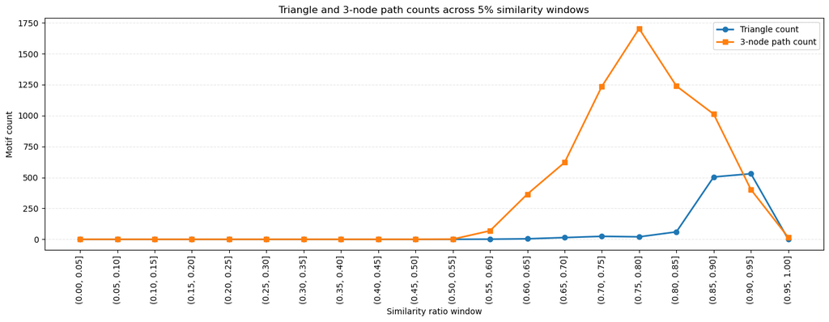